# Spam+Detector

## NLP (Natural Language Processing) with Python

## Spam Detector Model

Objective:

We will be building a SMS spam detector. The input data we have, to train the model is a file containing sms data and the classification label. Using this we shall build a Naive Bayes classifier model which will detect sms to be ham/spam.

## Step 1: Data Import

Import Data from SMSSpamCollection file.

Upload this file in your jupyter notebook directory and call the file directly.

Use pandas library to read data from the csv file.

```python
import pandas as pd
%matplotlib inline
import seaborn as sns
import warnings
warnings.filterwarnings('ignore')

msg=pd.read_csv('SMSSpamCollection',sep='\t',names=['label','msgs'])
msg.describe()
```

|  | label | msgs |
| --- | --- | --- |
| count | 5572 | 5572 |
| unique | 2 | 5169 |
| top | ham | Sorry, I'll call later |
| freq | 4825 | 30 |

## Step 2: Exploratory Data Analysis

Let us see the summary based on the labels column. group by label column and call describe function.

```python
msg.groupby('label').describe()
```

| label | msgs count | msgs unique | msgs top | msgs freq |
| --- | --- | --- | --- | --- |
| ham | 4825 | 4516 | Sorry, I'll call later | 30 |
| spam | 747 | 653 | Please call our customer service representativ... | 4 |

Create a new column which will store the length of the each sms.

## Step 3: Data Visualization

Let us plot the length distribution of the sms across labels.

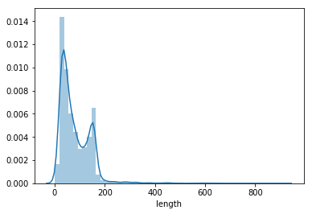

```python
msg['length']=msg['msgs'].apply(len)
sns.distplot(msg['length'])
```

The plot clearly shows that there are sms with very high number of words (>600).

Let us try to find the maximum length of sms. And also check what sms is that.

```python
msg['length'].describe()
```

```
count    5572.000000
mean       80.489950
std        59.942907
min         2.000000
25%        36.000000
50%        62.000000
75%       122.000000
max       910.000000
Name: length, dtype: float64
```

```python
msg[msg['length']==910]['msgs'].iloc[0]
```

```
"For me the love should start with attraction.i should feel that I need her every time around me.she should be the first thing which comes in my thoughts.I would start the day and end it with her.she should be there every time I dream.love will be then when my every breath has her name.my life shoul…
```

Let us try to explore the length based on labels to find if there is a trend observed.

```
array([<matplotlib.axes._subplots.AxesSubplot object at 0x000000000B8C7710>,
      dtype=object)
```

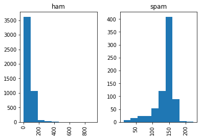

```python
msg.hist(column='length',by ='label')
```

Clearly, it is seen that the spam messages are long with more number of words. (peak =160)

The actual messages are short in length with average length around 50.

## Step 4: Data Cleaning and Preparation (Text Preprocessing)

The text data need to be cleaned before we use that to train the model. Let us do the below to extract significant words:

```
  1. Remove puctuations
  2. Remove stopwords
```

```python
import nltk
nltk.download('stopwords')
import string

def text_process(mess):
    """
    1. Remove punc
    2. Remove stopwords
    3. Return clean text words  list
    """

    nopunc = [char for char in mess if char not in string.punctuation]
    nopunc = ''.join(nopunc)
    return [word for word in nopunc.split() if word.lower() not in stopwords.words('english')]

msg['msgs'].head(3).apply(text_process)
```

```
0    [Go, jurong, point, crazy, Available, bugis, n...
1                       [Ok, lar, Joking, wif, u, oni]
2    [Free, entry, 2, wkly, comp, win, FA, Cup, fin...
Name: msgs, dtype: object
```

## Step 5: Vectorization

1. Count how many times does a word occur in each message (Known as term frequency)
2. Weigh the counts, so that frequent tokens get lower weight (inverse document frequency)

TF-IDF stands for term frequency-inverse document frequency, and the tf-idf weight is a weight often used in information retrieval and text mining. This weight is a statistical measure used to evaluate how important a word is to a document in a collection or corpus.

The importance increases proportionally to the number of times a word appears in the document but is offset by the frequency of the word in the corpus. Variations of the tf-idf weighting scheme are often used by search engines as a central tool in ranking a document's relevance given a user query.

```python
from sklearn.feature_extraction.text import CountVectorizer

bow_transformer = CountVectorizer(analyzer=text_process).fit(msg['msgs'])

print(len(bow_transformer.vocabulary_))
```

```
11425
```

## Step 6: Train & Test Data Preparation

Now we need to split the data to train & test sets which can be used to build and evaluate the model.

```python
from sklearn.cross_validation import train_test_split
msg_train,msg_test,label_train,label_test = train_test_split(msg['msgs'],msg['label'],test_size=0.3)
```

## Step 7: Build the Model using Train data

```python
from sklearn.feature_extraction.text import TfidfTransformer
from sklearn.naive_bayes import MultinomialNB

msg_bow = bow_transformer.transform(msg_train)
tfidf_transformer = TfidfTransformer().fit(msg_bow)
msg_tfidf=tfidf_transformer.transform(msg_bow)
spam_detect_model = MultinomialNB().fit(msg_tfidf,label_train)
```

## Step 8: Evaluate the model using Test Data

```python
msg_test_bow = bow_transformer.transform(msg_test)
tfidf_test_transformer = TfidfTransformer().fit(msg_test_bow)
msg_test_tfidf=tfidf_transformer.transform(msg_test_bow)
all_predict=spam_detect_model.predict(msg_test_tfidf)

from sklearn.metrics import classification_report
print(classification_report(label_test,all_predict))
```

```
             precision    recall  f1-score   support

        ham       0.96      1.00      0.98      1442
       spam       1.00      0.71      0.83       230

avg / total       0.96      0.96      0.96      1672
```

Thus, the model we built has turned out to be 96% accurate.

## Using pipeline feature in sklearn to build the model

```python
from sklearn.pipeline import Pipeline

pipeline = Pipeline([
    ('bow', CountVectorizer(analyzer=text_process)),  # strings to token integer counts
    ('tfidf', TfidfTransformer()),  # integer counts to weighted TF-IDF scores
    ('classifier', MultinomialNB()),  # train on TF-IDF vectors w/ Naive Bayes classifier
])
```

```python
pipeline.fit(msg_train,label_train)
```

```
Pipeline(memory=None,
     steps=[('bow', CountVectorizer(analyzer=<function text_process at 0x000000000C2199D8>,
        binary=False, decode_error='strict', dtype=<class 'numpy.int64'>,
        encoding='utf-8', input='content', lowercase=True, max_df=1.0,
        max_features=None, min_df=1, ngram_range=(1, 1), preprocesso...f=False, use_idf=True)), ('classifier', MultinomialNB(alpha=1.0, class_prior=None, fit_prior=True))])
```

```python
predictions = pipeline.predict(msg_test)
```

```python
print(classification_report(predictions,label_test))
```

```
             precision    recall  f1-score   support

        ham       1.00      0.96      0.98      1504
       spam       0.73      1.00      0.84       168

avg / total       0.97      0.96      0.97      1672
```